# Pima Indians Diabetes Prediction

## Feature Information

- **Pregnancies:** Number of times pregnant
- **GlucosePlasma:** Glucose concentration a 2 hours in an oral glucose tolerance test
- **BloodPressure:** Diastolic blood pressure (mm Hg)
- **SkinThickness:** Triceps skin fold thickness (mm)
- **Insulin:** 2-Hour serum insulin (mu U/ml)
- **BMI:** Body mass index (weight in kg/(height in m)^2)
- **DiabetesPedigreeFunction:** Diabetes pedigree function
- **Age:** Age (years)
- **Outcome:** Class variable (0 or 1)

## Exploratory Data Analysis

```python
import pandas as pd
import numpy as np
import matplotlib.pyplot as plt
import seaborn as sns
%matplotlib inline
plt.style.use('seaborn')

import sklearn
import warnings
warnings.filterwarnings("ignore")
print('Sklearn Ver: ' + str(sklearn.__version__))
```

```
Sklearn Ver: 0.22.2.post1
```

It is important to take a look at the data before starting our analysis, check the number of records and columns. This helps we see how the data is organized and to see if there are abnormalities.

```python
path = 'diabetes.csv'

df = pd.read_csv(path)
df_original = df
df.head()
```

|  | Pregnancies | Glucose | BloodPressure | SkinThickness | Insulin | BMI | DiabetesPedigreeFunction | Age | Outcome |
| --- | --- | --- | --- | --- | --- | --- | --- | --- | --- |
| 0 | 6 | 148 | 72 | 35 | 0 | 33.6 | 0.627 | 50 | 1 |
| 1 | 1 | 85 | 66 | 29 | 0 | 26.6 | 0.351 | 31 | 0 |
| 2 | 8 | 183 | 64 | 0 | 0 | 23.3 | 0.672 | 32 | 1 |
| 3 | 1 | 89 | 66 | 23 | 94 | 28.1 | 0.167 | 21 | 0 |
| 4 | 0 | 137 | 40 | 35 | 168 | 43.1 | 2.288 | 33 | 1 |

```python
# (n_rows, n_cols)
df.shape
```

```
(768, 9)
```

It seems that all features are numeric.

Checking for missing values. Machine learning algorithms (most of them) do not support **NaN** values.

```python
df.isna().sum()
```

```
Pregnancies                 0
Glucose                     0
BloodPressure               0
SkinThickness               0
Insulin                     0
BMI                         0
DiabetesPedigreeFunction    0
Age                         0
Outcome                     0
dtype: int64
```

Even though all features appear to be numeric, we must confirm all types of data in our data frame.

```python
df.info()
```

```
<class 'pandas.core.frame.DataFrame'>
RangeIndex: 768 entries, 0 to 767
Data columns (total 9 columns):
 #   Column                    Non-Null Count  Dtype
---  ------                    --------------  -----
 0   Pregnancies               768 non-null    int64
 1   Glucose                   768 non-null    int64
 2   BloodPressure             768 non-null    int64
 3   SkinThickness             768 non-null    int64
 4   Insulin                   768 non-null    int64
 5   BMI                       768 non-null    float64
 6   DiabetesPedigreeFunction  768 non-null    float64
 7   Age                       768 non-null    int64
 8   Outcome                   768 non-null    int64
dtypes: float64(2), int64(7)
memory usage: 54.1 KB
```

Checking basic statistics.

```python
df.describe()
```

|  | Pregnancies | Glucose | BloodPressure | SkinThickness | Insulin | BMI | DiabetesPedigreeFunction | Age | Outcome |
| --- | --- | --- | --- | --- | --- | --- | --- | --- | --- |
| count | 768.000000 | 768.000000 | 768.000000 | 768.000000 | 768.000000 | 768.000000 | 768.000000 | 768.000000 | 768.000000 |
| mean | 3.845052 | 120.894531 | 69.105469 | 20.536458 | 79.799479 | 31.992578 | 0.471876 | 33.240885 | 0.348958 |
| std | 3.369578 | 31.972618 | 19.355807 | 15.952218 | 115.244002 | 7.884160 | 0.331329 | 11.760232 | 0.476951 |
| min | 0.000000 | 0.000000 | 0.000000 | 0.000000 | 0.000000 | 0.000000 | 0.078000 | 21.000000 | 0.000000 |
| 25% | 1.000000 | 99.000000 | 62.000000 | 0.000000 | 0.000000 | 27.300000 | 0.243750 | 24.000000 | 0.000000 |
| 50% | 3.000000 | 117.000000 | 72.000000 | 23.000000 | 30.500000 | 32.000000 | 0.372500 | 29.000000 | 0.000000 |
| 75% | 6.000000 | 140.250000 | 80.000000 | 32.000000 | 127.250000 | 36.600000 | 0.626250 | 41.000000 | 1.000000 |
| max | 17.000000 | 199.000000 | 122.000000 | 99.000000 | 846.000000 | 67.100000 | 2.420000 | 81.000000 | 1.000000 |

There are some strange values like 'Glucose', 'BloodPressure', 'SkinThickness', 'Insulin' and 'BMI' equal to 0 (zero). I will deal with that later. First, let's take a look at whether our target variable ('Outcome') is balanced.

```python
df['Outcome'].value_counts()
```

```
0    500
1    268
Name: Outcome, dtype: int64
```

Our target is unbalanced, this may affect our prediction. I will deal with that in the next sections.

Let's plot histograms to see the features' distribution.

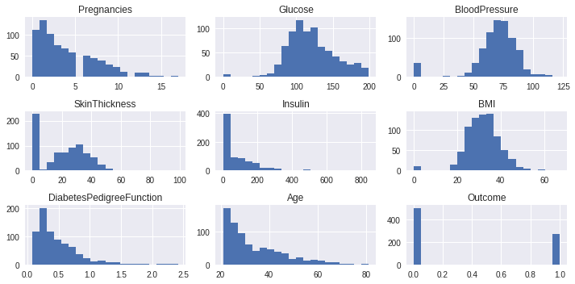

```python
df.hist(figsize=(10,5), bins=20);
plt.tight_layout()
```

Plotting density lines we can se a "smooth" distribution, helping to check for Gaussian distributions.

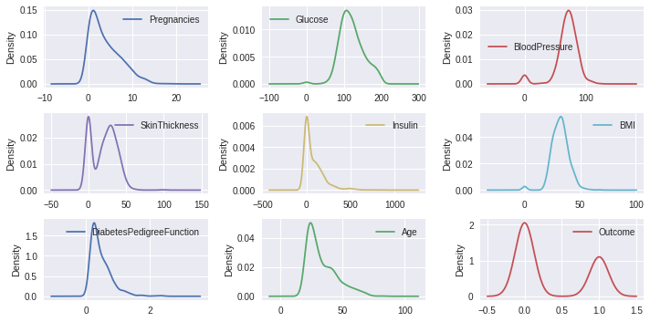

```python
df.plot(kind='kde', subplots=True, layout=(3,3), figsize=(10,5), sharex=False, sharey=False);
plt.tight_layout()
```

Boxplots show data dispersion and potential outliers.

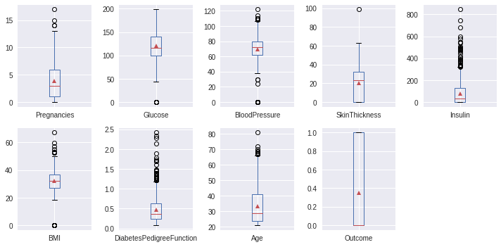

```python
df.plot(kind='box', subplots=True, layout=(2,5), figsize=(10,5), showmeans=True,
        sharex=False, sharey=False);
plt.tight_layout()
```

After exploring each feature independently, let's look for the correlation. Scatter plots are useful in this task, revealing patterns and linearity between variables.

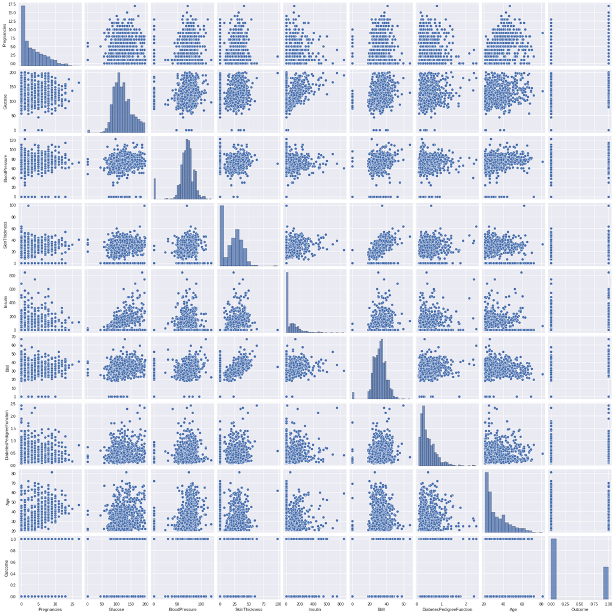

```python
sns.pairplot(df);
```

There are many methods for quantifying the correlations. One of the most popular is Person's Correlation, which assumes normaly distributed data and measures the linearity between variables.

I am going to plot a heatmap and use it as a correlarion matrix.

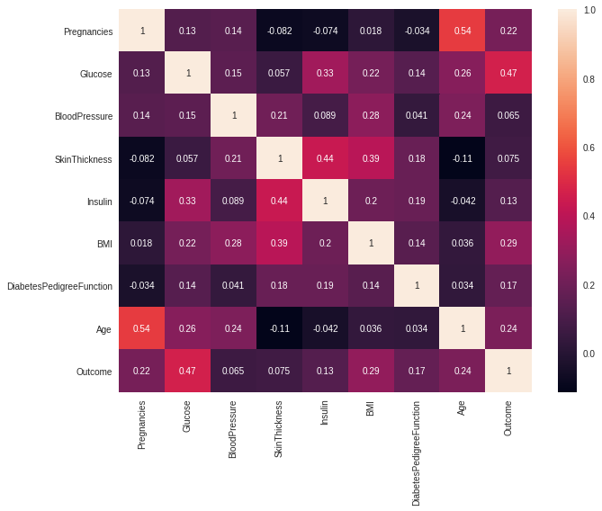

```python
plt.figure(figsize=(10,8))
sns.heatmap(df.corr(method='pearson'), annot=True)
plt.tight_layout()
```

Ranking the correlation between features and target.

```python
df.corr().iloc[:-1,-1].sort_values(ascending=False) * 100
```

```
Glucose                     46.658140
BMI                         29.269466
Age                         23.835598
Pregnancies                 22.189815
DiabetesPedigreeFunction    17.384407
Insulin                     13.054795
SkinThickness                7.475223
BloodPressure                6.506836
Name: Outcome, dtype: float64
```

## Handling Outliers

I don't know much about health data (whether a value is too high or too low), but there are extreme values that are unreasonable.

```python
def MinMaxValues(data, top, remove):
    """
    Returns the lowest/highest values from each dataframe column

    data: dataframe
    top: 'low' or 'high'
    """

    if(top == 'low'):
        sort = True
    elif(top == 'high'):
        sort = False

    values = {}

    for col in data.columns:
        values[col] = data[col].value_counts().sort_index(ascending=sort).iloc[:5].index

    values.pop(remove)

    return pd.DataFrame(values)
```

```python
# Checking the 5 lowest values
MinMaxValues(df, 'low', 'Outcome')
```

|  | Pregnancies | Glucose | BloodPressure | SkinThickness | Insulin | BMI | DiabetesPedigreeFunction | Age |
| --- | --- | --- | --- | --- | --- | --- | --- | --- |
| 0 | 0 | 0 | 0 | 0 | 0 | 0.0 | 0.078 | 21 |
| 1 | 1 | 44 | 24 | 7 | 14 | 18.2 | 0.084 | 22 |
| 2 | 2 | 56 | 30 | 8 | 15 | 18.4 | 0.085 | 23 |
| 3 | 3 | 57 | 38 | 10 | 16 | 19.1 | 0.088 | 24 |
| 4 | 4 | 61 | 40 | 11 | 18 | 19.3 | 0.089 | 25 |

Well, there are some values equals to 0 (zero) - 'Glucose', 'BloodPressure', 'SkinThickness', 'Insulin' and 'BMI'. I will take these records as wrong and fill them in with their respective median.

```python
for col in ['Glucose', 'BloodPressure', 'SkinThickness', 'Insulin', 'BMI']:
    df.loc[df[col] == 0, col] = df[col].median()
```

```python
# Checking the 5 lowest values
MinMaxValues(df, 'low', 'Outcome')
```

|  | Pregnancies | Glucose | BloodPressure | SkinThickness | Insulin | BMI | DiabetesPedigreeFunction | Age |
| --- | --- | --- | --- | --- | --- | --- | --- | --- |
| 0 | 0 | 44 | 24 | 7 | 14.0 | 18.2 | 0.078 | 21 |
| 1 | 1 | 56 | 30 | 8 | 15.0 | 18.4 | 0.084 | 22 |
| 2 | 2 | 57 | 38 | 10 | 16.0 | 19.1 | 0.085 | 23 |
| 3 | 3 | 61 | 40 | 11 | 18.0 | 19.3 | 0.088 | 24 |
| 4 | 4 | 62 | 44 | 12 | 22.0 | 19.4 | 0.089 | 25 |

Now they seem reasonable.

```python
# Checking the 5 highest values
MinMaxValues(df, 'high', 'Outcome')
```

|  | Pregnancies | Glucose | BloodPressure | SkinThickness | Insulin | BMI | DiabetesPedigreeFunction | Age |
| --- | --- | --- | --- | --- | --- | --- | --- | --- |
| 0 | 17 | 199 | 122 | 99 | 846.0 | 67.1 | 2.420 | 81 |
| 1 | 15 | 198 | 114 | 63 | 744.0 | 59.4 | 2.329 | 72 |
| 2 | 14 | 197 | 110 | 60 | 680.0 | 57.3 | 2.288 | 70 |
| 3 | 13 | 196 | 108 | 56 | 600.0 | 55.0 | 2.137 | 69 |
| 4 | 12 | 195 | 106 | 54 | 579.0 | 53.2 | 1.893 | 68 |

The number of pregnancies is very high, but it is not impossible to give birth to 17 babies. Due to lack of knowledge in the area, I will accept the other values as correct.

After these operations, I will take another look at data distribution.

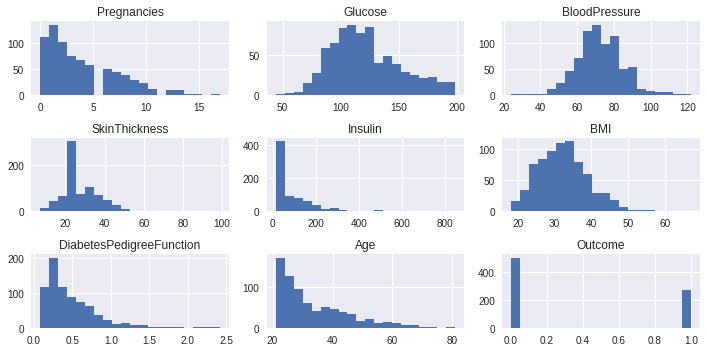

```python
df.hist(figsize=(10,5), bins=20);
plt.tight_layout()
```

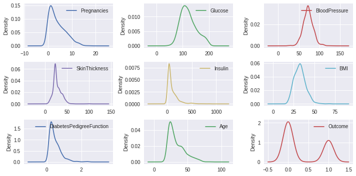

```python
df.plot(kind='kde', subplots=True, layout=(3,3), figsize=(10,5), sharex=False, sharey=False);
plt.tight_layout()
```

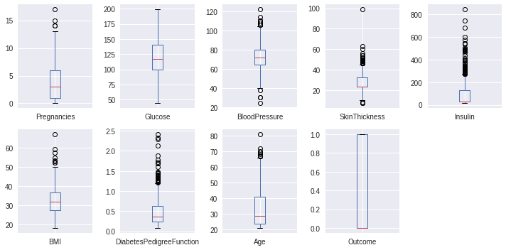

```python
df.plot(kind='box', subplots=True, layout=(2,5), figsize=(10,5), sharex=False, sharey=False);
plt.tight_layout()
```

## Feature Selection

It is not easy to determine which features are important to our model. There are features that contribute to noise, impairing the forecast. One way to determine the features is through the **Univariate Selection** approach, which selects the variables based on univariate statistical test.

There are 8 features, we do a test selecting the 4 most relevant. The statistical test that we will use is **Chi-Squared**.

```python
from sklearn.feature_selection import SelectKBest
from sklearn.feature_selection import chi2

# Spliting the data into input and output (the 'Outcome' column is our target)
X = df.values[:,:-1]
y = df.values[:,-1]

# chi2: Chi-Squared
# k = 4: top 4 features
test = SelectKBest(score_func = chi2, k = 4)
fit = test.fit(X,y)

# Summarizing Scores
print("Scores:")
print(fit.scores_)
print()

# Summarizing Selected features
features = fit.transform(X)
print('Selected features:')
print(features[0:5,:])
```

```
Scores:
[ 111.51969064 1418.44239729   42.58250709   85.43128164 1989.58939433
  108.93372502    5.39268155  181.30368904]

Selected features:
[[  6.  148.   30.5  50. ]
 [  1.   85.   30.5  31. ]
 [  8.  183.   30.5  32. ]
 [  1.   89.   94.   21. ]
 [  0.  137.  168.   33. ]]
```

```python
# Renaming selected features dataframe columns
features = pd.DataFrame(features)
features.columns = df.columns[sorted(pd.Series(fit.scores_).sort_values(ascending=False).iloc[:4].index)]
features.head()
```

|  | Pregnancies | Glucose | Insulin | Age |
| --- | --- | --- | --- | --- |
| 0 | 6.0 | 148.0 | 30.5 | 50.0 |
| 1 | 1.0 | 85.0 | 30.5 | 31.0 |
| 2 | 8.0 | 183.0 | 30.5 | 32.0 |
| 3 | 1.0 | 89.0 | 94.0 | 21.0 |
| 4 | 0.0 | 137.0 | 168.0 | 33.0 |

```python
# Joining our target
features['Outcome'] = df['Outcome']
features.head()
```

|  | Pregnancies | Glucose | Insulin | Age | Outcome |
| --- | --- | --- | --- | --- | --- |
| 0 | 6.0 | 148.0 | 30.5 | 50.0 | 1 |
| 1 | 1.0 | 85.0 | 30.5 | 31.0 | 0 |
| 2 | 8.0 | 183.0 | 30.5 | 32.0 | 1 |
| 3 | 1.0 | 89.0 | 94.0 | 21.0 | 0 |
| 4 | 0.0 | 137.0 | 168.0 | 33.0 | 1 |

## Data Preprocessing

Each machine learning algorithm has its peculiarity, expecting some data requirements when fed. I will try three techniques: **Data Normalization**, **Data Standardization** and **Power Transformation**

### Data Normalization

The normalizer function rescales each input row to have unit norm. This process does not depend on the distribution of the samples. It is useful for algorithms that use distance measurement.

```python
from sklearn.preprocessing import Normalizer

# Spliting the data into input and output
X = features.values[:,:-1]
y = features.values[:,-1]

# Normalizing
X_normalized = Normalizer().fit_transform(X)
```

### Data Standardization

This process transforms a normally distributed random variable with mean u and standard deviation s into a standard normal random variable with mean 0 and standard deviation equal to 1.

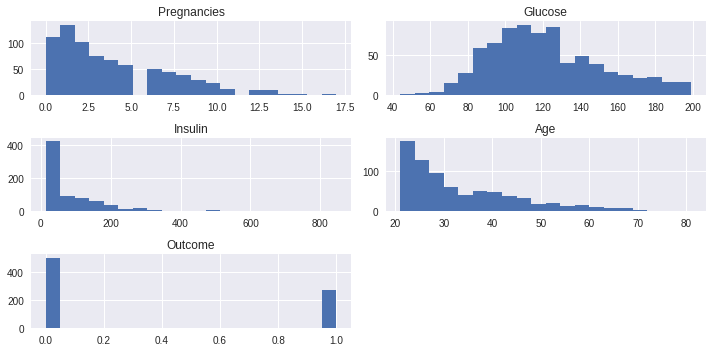

```python
# Checking features' normality
features.hist(figsize=(10,5), bins=20);
plt.tight_layout()
```

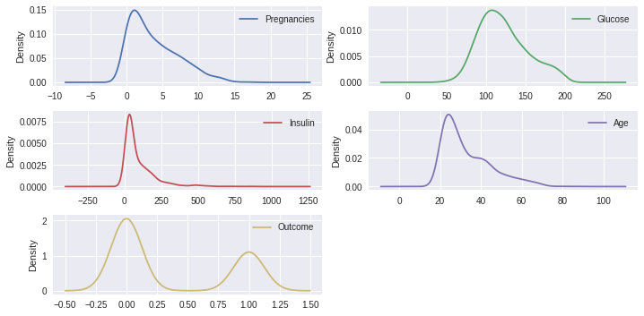

```python
features.plot(kind='kde', subplots=True, layout=(3,2), figsize=(10,5), sharex=False, sharey=False);
plt.tight_layout()
```

We can see that data is not exactly normally distributed, but we will continue anyway.

```python
from sklearn.preprocessing import StandardScaler

# Spliting the data into input and output
X = features.values[:,:-1]
y = features.values[:,-1]

# Standardizing the data
X_standard = StandardScaler().fit_transform(X)
```

### Power Transformation

The previous transformation expected the data was normally distributed. Trying to improve this, we will use Power Transform, which will use a transformation that makes the distributions normal (or something close).

```python
from sklearn.preprocessing import PowerTransformer

# PowerTransformer performs operations on data to make it normally distributed
# Activating "standardize" key word performs standardization
power = PowerTransformer(method='yeo-johnson', standardize=True)
X = features.values[:,:-1]
y = features.values[:,-1]

X_power = power.fit_transform(X)
```

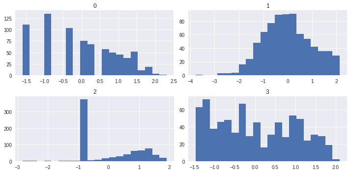

```python
# Checking the transformation results
pd.DataFrame(X_power).hist(figsize=(10,5), bins=20);
plt.tight_layout()
```

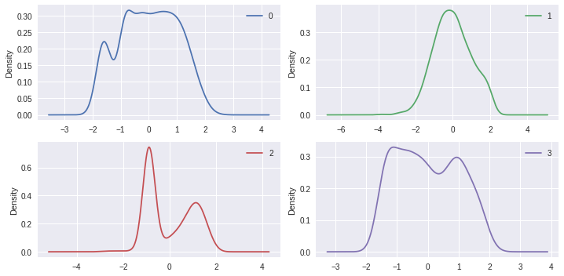

```python
pd.DataFrame(X_power).plot(kind='kde', subplots=True, layout=(2,2), figsize=(10,5), sharex=False, sharey=False);
plt.tight_layout()
```

## Model Selection

Testing differents models to find the one that make the best prediction.

```python
from sklearn.model_selection import train_test_split
from sklearn.model_selection import cross_val_score
from sklearn.model_selection import StratifiedKFold
from sklearn.metrics import classification_report
from sklearn.metrics import confusion_matrix
from sklearn.metrics import accuracy_score
from sklearn.linear_model import LogisticRegression
from sklearn.tree import DecisionTreeClassifier
from sklearn.neighbors import KNeighborsClassifier
from sklearn.discriminant_analysis import LinearDiscriminantAnalysis
from sklearn.naive_bayes import GaussianNB
from sklearn.svm import SVC
from sklearn.linear_model import SGDClassifier
```

```python
# Processed data dictionary
X = {}

# All features without transformations original
X['All_Original'] = df_original.values[:,:-1]

# All features without transformations cleanned
X['All_Cleanned'] = df.values[:,:-1]

# Selected features without transformations
X['Selected_Cleanned'] = features.values[:,:-1]

# Selected features Normalized
X['Normalized'] = X_normalized

# Selected features Standardized
X['Standardized'] = X_standard

# Selected features Power Transformed
X['Power_Transformed'] = X_power

y = df.values[:,-1]
```

Importing some algorithms. Due to imbalance, I will define some penalized algorithms.

```python
# Spot Check Algorithms
models = []
models.append(('LR', LogisticRegression()))
models.append(('LDA', LinearDiscriminantAnalysis()))
models.append(('KNN', KNeighborsClassifier()))
models.append(('CART', DecisionTreeClassifier(random_state=101)))
models.append(('NB', GaussianNB()))
models.append(('SVM', SVC(gamma='auto', random_state=101)))
models.append(('SGD', SGDClassifier(random_state=101)))

# Penalized algorithms
models.append(('LR_Penalized', LogisticRegression(class_weight='balanced')))
models.append(('SVM_Penalized', SVC(kernel='linear',
                                    class_weight='balanced',
                                    probability=True, random_state=101)))
models.append(('CART_Penalized', DecisionTreeClassifier(class_weight='balanced',
                                                        random_state=101)))
models.append(('SGD_Penalized', SGDClassifier(class_weight='balanced',
                                              random_state=101)))

# Store all results
all_results = {}
all_resumed = {}

# Evaluate each model in turn
for feat in X.keys():
    all_results[feat] = {}
    all_resumed[feat] = {}
    X_train, X_validation, y_train, y_validation = train_test_split(X[feat], y, test_size=0.20, random_state=101)
    for name, model in models:
        kfold = StratifiedKFold(n_splits=10, random_state=101, shuffle=True)
        all_results[feat].update({name: cross_val_score(model, X_train, y_train, cv=kfold, scoring='accuracy')})
        all_resumed[feat].update({name: {'Mean': np.round(all_results[feat][name].mean(), 4)}})
        all_resumed[feat][name].update({'Std': np.round(all_results[feat][name].std(), 4)})
```

```python
# Algorithm comparison
for feat in X.keys():
    print(feat + ':')
    print(pd.DataFrame(all_resumed[feat]).T)
    print()
```

```
All_Original:
                  Mean     Std
LR              0.7510  0.0848
LDA             0.7672  0.0681
KNN             0.6841  0.0705
CART            0.6806  0.0493
NB              0.7410  0.0412
SVM             0.6466  0.0065
SGD             0.5865  0.1029
LR_Penalized    0.7428  0.0631
SVM_Penalized   0.7492  0.0570
CART_Penalized  0.6743  0.0440
SGD_Penalized   0.5989  0.1241

All_Cleanned:
                  Mean     Std
LR              0.7510  0.0848
LDA             0.7672  0.0681
KNN             0.6841  0.0705
CART            0.6806  0.0493
NB              0.7410  0.0412
SVM             0.6466  0.0065
SGD             0.5865  0.1029
LR_Penalized    0.7428  0.0631
SVM_Penalized   0.7492  0.0570
CART_Penalized  0.6743  0.0440
SGD_Penalized   0.5989  0.1241

Selected_Cleanned:
                  Mean     Std
LR              0.7459  0.0587
LDA             0.7459  0.0604
KNN             0.6969  0.0800
CART            0.6935  0.0694
NB              0.7279  0.0719
SVM             0.6417  0.0170
SGD             0.4772  0.1272
LR_Penalized    0.7280  0.0705
SVM_Penalized   0.7345  0.0623
CART_Penalized  0.7018  0.0546
```

[output cut: 28 more lines]

```
SGD_Penalized   0.6515  0.0617

Power_Transformed:
                  Mean     Std
LR              0.7476  0.0587
LDA             0.7410  0.0557
KNN             0.7277  0.0608
CART            0.6903  0.0800
NB              0.7295  0.0667
SVM             0.7410  0.0710
SGD             0.6871  0.0595
LR_Penalized    0.7197  0.0697
SVM_Penalized   0.7229  0.0702
CART_Penalized  0.7002  0.0578
SGD_Penalized   0.6578  0.0843
```

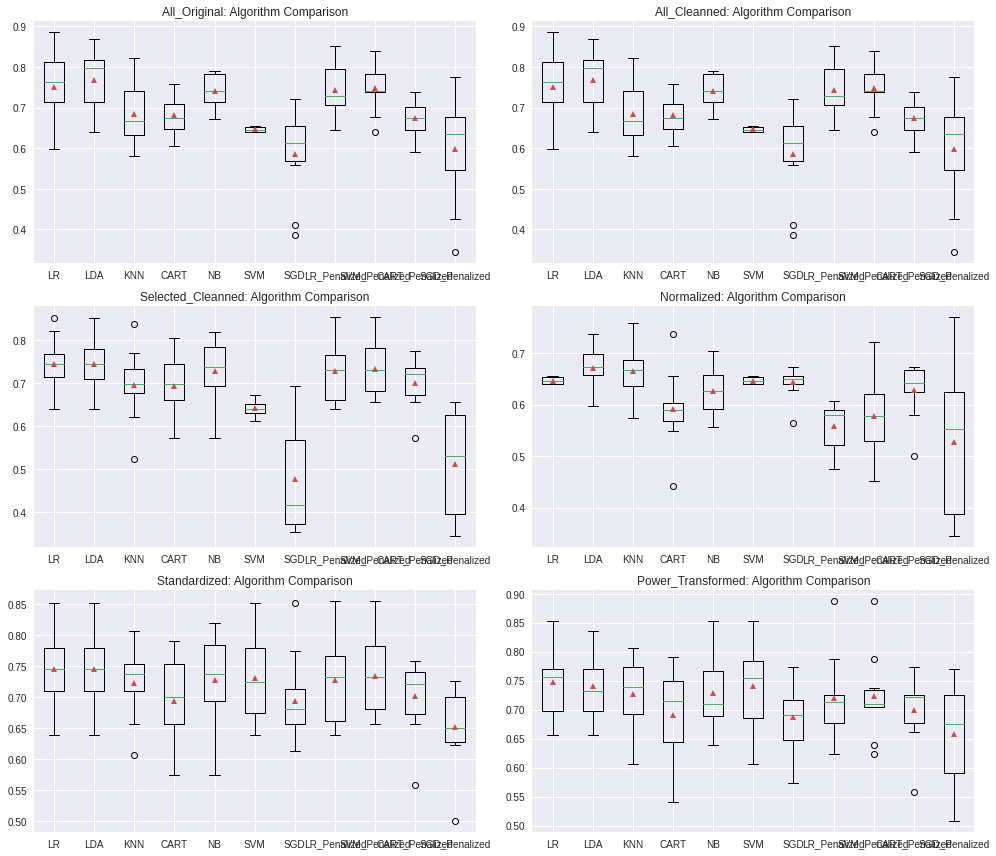

```python
# Plotting algorithm comparison
fig, axes = plt.subplots(3,2, figsize=(14,12))

i, j = 0, 0
for feat in X.keys():
    axes[i,j].boxplot(all_results[feat].values(),
                      labels=all_results[feat].keys(), showmeans=True)
    axes[i,j].set_title(feat + ': Algorithm Comparison')
    j += 1
    if(j > 1):
        i += 1
        j = 0

plt.tight_layout()
```

The best result is from the **LDA** in **All_Original**/**All_Cleanned** (same accuracy).

Although **accuracy** is a good indicator, our class is unbalanced, so we need other measures to compare the models.

```python
# Macro metrics treats all classes as equal
scores = ['accuracy', 'precision_macro', 'recall_macro', 'f1_macro']

# Evaluate each model in turn
for feat in X.keys():
    all_results[feat] = {}
    all_resumed[feat] = {}
    X_train, X_validation, y_train, y_validation = train_test_split(X[feat], y, test_size=0.20, random_state=101)
    for name, model in models:
        kfold = StratifiedKFold(n_splits=10, random_state=101, shuffle=True)
        all_results[feat].update({name: {}})
        all_resumed[feat].update({name: {}})
        for score in scores:
          all_results[feat][name].update({score: cross_val_score(model, X_train, y_train, cv=kfold, scoring=score)})
          all_resumed[feat][name].update({score: str(np.round(all_results[feat][name][score].mean(), 4)) + ' (' +
                                                 str(np.round(all_results[feat][name][score].std(), 4)) + ')'})
```

```python
# list(X.keys())[0] means the first data case: All_Original
pd.DataFrame(all_resumed[list(X.keys())[0]]).T
```

|  | accuracy | precision_macro | recall_macro | f1_macro |
| --- | --- | --- | --- | --- |
| LR | 0.751 (0.0848) | 0.7339 (0.1049) | 0.6987 (0.0986) | 0.7059 (0.102) |
| LDA | 0.7672 (0.0681) | 0.7516 (0.0837) | 0.72 (0.085) | 0.7269 (0.0856) |
| KNN | 0.6841 (0.0705) | 0.6518 (0.0864) | 0.6417 (0.0813) | 0.6422 (0.0836) |
| CART | 0.6806 (0.0493) | 0.6579 (0.0482) | 0.6485 (0.0403) | 0.6463 (0.0463) |
| NB | 0.741 (0.0412) | 0.7163 (0.0493) | 0.7059 (0.0532) | 0.7085 (0.0517) |
| SVM | 0.6466 (0.0065) | 0.3233 (0.0032) | 0.5 (0.0) | 0.3927 (0.0024) |
| SGD | 0.5865 (0.1029) | 0.5759 (0.1582) | 0.5469 (0.064) | 0.4576 (0.0917) |
| LR_Penalized | 0.7428 (0.0631) | 0.7285 (0.065) | 0.7435 (0.0693) | 0.7297 (0.0663) |
| SVM_Penalized | 0.7492 (0.057) | 0.7298 (0.0636) | 0.741 (0.0714) | 0.7316 (0.0649) |
| CART_Penalized | 0.6743 (0.044) | 0.6458 (0.0489) | 0.6435 (0.0509) | 0.6415 (0.0489) |
| SGD_Penalized | 0.5989 (0.1241) | 0.5867 (0.2257) | 0.57 (0.0923) | 0.4847 (0.1371) |

When we look at **precision**, **recall** and **f1**, we realize that it is not a good idea to rely on **accuracy** alone.

Let's make some predictions with **SVM** case and print a confusion matrix.

```python
X_train, X_validation, y_train, y_validation = train_test_split(X['All_Original'], y, test_size=0.20, random_state=101)

model = SVC(gamma='auto', random_state=101)
model.fit(X_train, y_train)
predictions = model.predict(X_validation)

print('Confusion Matrix:')
print(confusion_matrix(y_validation, predictions))
print()
print('Classification Report:')
print(classification_report(y_validation, predictions))
```

```
Confusion Matrix:
[[103   0]
 [ 51   0]]

Classification Report:
              precision    recall  f1-score   support

         0.0       0.67      1.00      0.80       103
         1.0       0.00      0.00      0.00        51

    accuracy                           0.67       154
   macro avg       0.33      0.50      0.40       154
weighted avg       0.45      0.67      0.54       154
```

This example shows that the model is biased, "forecasting" only the majority class.

## Handling Imbalaced Class

As we cannot acquire more data, we need to use other methods such as **Undersampling Majority Class**, **Oversampling Minority Class** and generate synthetic samples using **SMOTE**. After applying each technique, we will evaluate the most appropriate one.

#### Undersampling Majority Class

Random undersampling involves randomly selecting examples from the majority class to delete from the training dataset. A drawback is that we are removing information that may be valuable. This could lead to underfitting and poor generalization to the test set.

```python
# Check version number
import imblearn
print('Imblearn Ver: ' + str(imblearn.__version__))
```

```
Imblearn Ver: 0.4.3
```

```python
# Random undersampling to balance the class distribution
from imblearn.under_sampling import RandomUnderSampler
```

```python
# Macro metrics treats all classes as equal
scores = ['accuracy', 'precision_macro', 'recall_macro', 'f1_macro']

model_name = [m[0] for m in models]
cv_df = pd.DataFrame(columns=scores, index=model_name)

# Evaluate each model in turn
X_train, X_validation, y_train, y_validation = train_test_split(X['All_Original'], y, test_size=0.20,
                                                                stratify=y, random_state=101)
# define undersample strategy
undersample = RandomUnderSampler(sampling_strategy='majority')
# fit and apply the transform
X_train, y_train = undersample.fit_resample(X_train, y_train)

for score in scores:
  for name, model in models:
    kfold = StratifiedKFold(n_splits=10, random_state=101, shuffle=True)
    cv_results = cross_val_score(model, X_train, y_train, cv=kfold, scoring=score)
    cv_df.loc[name, score] = str(np.round(cv_results.mean(), 4))+' ('+str(np.round(cv_results.std(), 4))+')'
```

```python
cv_df
```

|  | accuracy | precision_macro | recall_macro | f1_macro |
| --- | --- | --- | --- | --- |
| LR | 0.7265 (0.0664) | 0.7287 (0.066) | 0.7265 (0.0665) | 0.7255 (0.0671) |
| LDA | 0.7402 (0.085) | 0.7467 (0.0833) | 0.7404 (0.0846) | 0.7377 (0.0871) |
| KNN | 0.7008 (0.0753) | 0.7074 (0.0765) | 0.7008 (0.0747) | 0.6982 (0.076) |
| CART | 0.6961 (0.0748) | 0.7017 (0.0763) | 0.6959 (0.0741) | 0.694 (0.0748) |
| NB | 0.724 (0.0946) | 0.7303 (0.0964) | 0.724 (0.095) | 0.7216 (0.0962) |
| SVM | 0.5001 (0.0257) | 0.481 (0.2164) | 0.5089 (0.0238) | 0.3665 (0.0411) |
| SGD | 0.5774 (0.0871) | 0.6066 (0.1976) | 0.5793 (0.0828) | 0.4982 (0.1332) |
| LR_Penalized | 0.7172 (0.0784) | 0.7196 (0.0786) | 0.7171 (0.0787) | 0.7159 (0.0793) |
| SVM_Penalized | 0.7402 (0.0824) | 0.7478 (0.0796) | 0.7403 (0.082) | 0.7368 (0.086) |
| CART_Penalized | 0.7007 (0.0823) | 0.705 (0.0835) | 0.7003 (0.0821) | 0.6988 (0.0828) |
| SGD_Penalized | 0.6146 (0.0675) | 0.6524 (0.1448) | 0.6175 (0.0668) | 0.5661 (0.1081) |

```python
model = LogisticRegression(class_weight='balanced') # Penalized
model.fit(X_train, y_train)
predictions = model.predict(X_validation)

print('Confusion Matrix:')
print(confusion_matrix(y_validation, predictions))
print()
print('Classification Report:')
print(classification_report(y_validation, predictions))
```

```
Confusion Matrix:
[[74 26]
 [20 34]]

Classification Report:
              precision    recall  f1-score   support

         0.0       0.79      0.74      0.76       100
         1.0       0.57      0.63      0.60        54

    accuracy                           0.70       154
   macro avg       0.68      0.68      0.68       154
weighted avg       0.71      0.70      0.70       154
```

#### Oversampling Minority Class

Random oversampling involves randomly duplicating examples from the minority class and adding them to the training dataset.

```python
# Random oversampling to balance the class distribution
from imblearn.over_sampling import RandomOverSampler
```

```python
# Macro metrics treats all classes as equal
scores = ['accuracy', 'precision_macro', 'recall_macro', 'f1_macro']

model_name = [m[0] for m in models]
cv_df = pd.DataFrame(columns=scores, index=model_name)

# Evaluate each model in turn
X_train, X_validation, y_train, y_validation = train_test_split(X['All_Original'], y, test_size=0.20,
                                                                stratify=y, random_state=101)
# define oversampling strategy
oversample = RandomOverSampler(sampling_strategy='minority')
# fit and apply the transform
X_train, y_train = oversample.fit_resample(X_train, y_train)

for score in scores:
  for name, model in models:
    kfold = StratifiedKFold(n_splits=10, random_state=101, shuffle=True)
    cv_results = cross_val_score(model, X_train, y_train, cv=kfold, scoring=score)
    cv_df.loc[name, score] = str(np.round(cv_results.mean(), 4))+' ('+str(np.round(cv_results.std(), 4))+')'
```

```python
cv_df
```

|  | accuracy | precision_macro | recall_macro | f1_macro |
| --- | --- | --- | --- | --- |
| LR | 0.7425 (0.0376) | 0.7461 (0.0353) | 0.7425 (0.0376) | 0.7413 (0.0386) |
| LDA | 0.7488 (0.0347) | 0.7538 (0.0308) | 0.7488 (0.0347) | 0.7471 (0.0367) |
| KNN | 0.7488 (0.0508) | 0.7518 (0.0518) | 0.7488 (0.0508) | 0.7481 (0.0507) |
| CART | 0.8212 (0.0379) | 0.8259 (0.0397) | 0.8212 (0.0379) | 0.8207 (0.038) |
| NB | 0.7263 (0.0351) | 0.7309 (0.0324) | 0.7263 (0.0351) | 0.7245 (0.0373) |
| SVM | 0.8662 (0.043) | 0.8962 (0.0262) | 0.8662 (0.043) | 0.863 (0.0461) |
| SGD | 0.585 (0.057) | 0.6433 (0.0646) | 0.585 (0.057) | 0.5401 (0.0918) |
| LR_Penalized | 0.7425 (0.0376) | 0.7461 (0.0353) | 0.7425 (0.0376) | 0.7413 (0.0386) |
| SVM_Penalized | 0.7463 (0.0362) | 0.7525 (0.0323) | 0.7463 (0.0362) | 0.7443 (0.0382) |
| CART_Penalized | 0.8212 (0.0379) | 0.8259 (0.0397) | 0.8212 (0.0379) | 0.8207 (0.038) |
| SGD_Penalized | 0.585 (0.057) | 0.6433 (0.0646) | 0.585 (0.057) | 0.5401 (0.0918) |

The best model is **SVM**. Let's make predictions.

```python
model = SVC(gamma='auto', random_state=101)
model.fit(X_train, y_train)
predictions = model.predict(X_validation)

print('Confusion Matrix:')
print(confusion_matrix(y_validation, predictions))
print()
print('Classification Report:')
print(classification_report(y_validation, predictions))
```

```
Confusion Matrix:
[[100   0]
 [ 54   0]]

Classification Report:
              precision    recall  f1-score   support

         0.0       0.65      1.00      0.79       100
         1.0       0.00      0.00      0.00        54

    accuracy                           0.65       154
   macro avg       0.32      0.50      0.39       154
weighted avg       0.42      0.65      0.51       154
```

The forecast result is inconsistent when compared to **Cross-Validation**. The high scores are due to (simple) oversampling, as we randomly duplicate examples from the minority class and adding them to the training dataset, making the model predict exactly the same as the samples used in the training. It is the same effect as data leakage.

Applying **CART**, the second best result in Cross-Validation, in our validation data.

```python
model = DecisionTreeClassifier(random_state=101)
model.fit(X_train, y_train)
predictions = model.predict(X_validation)

print('Confusion Matrix:')
print(confusion_matrix(y_validation, predictions))
print()
print('Classification Report:')
print(classification_report(y_validation, predictions))
```

```
Confusion Matrix:
[[84 16]
 [22 32]]

Classification Report:
              precision    recall  f1-score   support

         0.0       0.79      0.84      0.82       100
         1.0       0.67      0.59      0.63        54

    accuracy                           0.75       154
   macro avg       0.73      0.72      0.72       154
weighted avg       0.75      0.75      0.75       154
```

#### Synthetic Samples (SMOTE)

SMOTE is another way of oversampling, selecting examples that are close in the feature space, drawing a line between the examples in the feature space and drawing a new sample at a point along that line.

Splitting data into train and test.

```python
X_train, X_validation, y_train, y_validation = train_test_split(X['All_Original'], y, test_size=0.20,
                                                                stratify=y, random_state=101)
```

Summarizing the number of examples in each class.

```python
from collections import Counter

# summarize class distribution
counter = Counter(y_train)
print(counter)
```

```
Counter({0.0: 400, 1.0: 214})
```

Creating a scatter plot of the dataset and color the examples for each class a different color to clearly see the spatial nature of the class imbalance.

[figure not shown]

```python
import numpy as np

plt.figure(figsize=(10,6))

color = ['blue', 'orange']
# scatter plot of examples by class label
for label, _ in counter.items():
  row_ix = np.where(y_train == label)[0]
  # Taking advantage of the coincidence of the label having the same numbering
  # as the color index
  plt.scatter(X_train[row_ix, 1], X_train[row_ix, 7],
              alpha=0.5, label=str(label), c=color[int(label)])
plt.legend(['Diabetic', 'Non-Diabetic'], frameon=True, facecolor='w', fontsize=12);
```

```python
from imblearn.over_sampling import SMOTE

# Transform the dataset
oversample = SMOTE(random_state=101)
X_train, y_train = oversample.fit_resample(X_train, y_train)
```

```python
# Summarize the new class distribution
counter = Counter(y_train)
print(counter)
```

```
Counter({0.0: 400, 1.0: 400})
```

[figure not shown]

```python
plt.figure(figsize=(10,6))

color = ['blue', 'orange']
# scatter plot of examples by class label
for label, _ in counter.items():
  row_ix = np.where(y_train == label)[0]
  # Taking advantage of the coincidence of the label having the same numbering
  # as the color index
  plt.scatter(X_train[row_ix, 1], X_train[row_ix, 7],
              alpha=0.5, label=str(label), c=color[int(label)])
plt.legend(['Diabetic', 'Non-Diabetic'], frameon=True, facecolor='w', fontsize=12);
```

```python
# Macro metrics treats all classes as equal
scores = ['accuracy', 'precision_macro', 'recall_macro', 'f1_macro']

model_name = [m[0] for m in models]
cv_df = pd.DataFrame(columns=scores, index=model_name)

# Evaluate each model in turn

for score in scores:
  for name, model in models:
    kfold = StratifiedKFold(n_splits=10, random_state=101, shuffle=True)
    cv_results = cross_val_score(model, X_train, y_train, cv=kfold, scoring=score)
    cv_df.loc[name, score] = str(np.round(cv_results.mean(), 4))+' ('+str(np.round(cv_results.std(), 4))+')'
```

```python
cv_df
```

|  | accuracy | precision_macro | recall_macro | f1_macro |
| --- | --- | --- | --- | --- |
| LR | 0.7725 (0.0348) | 0.774 (0.0339) | 0.7725 (0.0348) | 0.7721 (0.0351) |
| LDA | 0.7612 (0.0323) | 0.7652 (0.031) | 0.7612 (0.0323) | 0.7602 (0.0329) |
| KNN | 0.7662 (0.0454) | 0.7749 (0.0473) | 0.7662 (0.0454) | 0.7644 (0.0459) |
| CART | 0.7588 (0.0454) | 0.7613 (0.0454) | 0.7588 (0.0454) | 0.7581 (0.0458) |
| NB | 0.7437 (0.0187) | 0.7465 (0.0204) | 0.7437 (0.0187) | 0.7431 (0.0185) |
| SVM | 0.6938 (0.0392) | 0.8108 (0.0157) | 0.6938 (0.0392) | 0.6602 (0.0511) |
| SGD | 0.6325 (0.066) | 0.6737 (0.0787) | 0.6325 (0.066) | 0.5957 (0.1043) |
| LR_Penalized | 0.7725 (0.0348) | 0.774 (0.0339) | 0.7725 (0.0348) | 0.7721 (0.0351) |
| SVM_Penalized | 0.7612 (0.0377) | 0.765 (0.0366) | 0.7612 (0.0377) | 0.7603 (0.0382) |
| CART_Penalized | 0.7588 (0.0454) | 0.7613 (0.0454) | 0.7588 (0.0454) | 0.7581 (0.0458) |
| SGD_Penalized | 0.6325 (0.066) | 0.6737 (0.0787) | 0.6325 (0.066) | 0.5957 (0.1043) |

```python
model = KNeighborsClassifier()
model.fit(X_train, y_train)
predictions = model.predict(X_validation)

print('Confusion Matrix:')
print(confusion_matrix(y_validation, predictions))
print()
print('Classification Report:')
print(classification_report(y_validation, predictions))
```

```
Confusion Matrix:
[[71 29]
 [20 34]]

Classification Report:
              precision    recall  f1-score   support

         0.0       0.78      0.71      0.74       100
         1.0       0.54      0.63      0.58        54

    accuracy                           0.68       154
   macro avg       0.66      0.67      0.66       154
weighted avg       0.70      0.68      0.69       154
```

### Combining SMOTE and Undersampling

```python
# example of both undersampling and oversampling
from imblearn.combine import SMOTEENN
```

```python
# Macro metrics treats all classes as equal
scores = ['accuracy', 'precision_macro', 'recall_macro', 'f1_macro']

model_name = [m[0] for m in models]
cv_df = pd.DataFrame(columns=scores, index=model_name)

# Evaluate each model in turn
X_train, X_validation, y_train, y_validation = train_test_split(X['All_Original'], y, test_size=0.20,
                                                                stratify=y, random_state=101)
# define oversampling followed by undersampling strategy
overundersample = SMOTEENN(sampling_strategy=0.81, random_state=101)
# fit and apply the transform
X_train, y_train = overundersample.fit_resample(X_train, y_train)

for score in scores:
  for name, model in models:
    kfold = StratifiedKFold(n_splits=10, random_state=101, shuffle=True)
    cv_results = cross_val_score(model, X_train, y_train, cv=kfold, scoring=score)
    cv_df.loc[name, score] = str(np.round(cv_results.mean(), 4))+' ('+str(np.round(cv_results.std(), 4))+')'
```

```python
cv_df
```

|  | accuracy | precision_macro | recall_macro | f1_macro |
| --- | --- | --- | --- | --- |
| LR | 0.9221 (0.0492) | 0.9234 (0.0472) | 0.9222 (0.0518) | 0.921 (0.0501) |
| LDA | 0.919 (0.0455) | 0.9246 (0.0408) | 0.9147 (0.0484) | 0.9168 (0.0474) |
| KNN | 0.9565 (0.0375) | 0.9568 (0.038) | 0.9579 (0.0356) | 0.9562 (0.0376) |
| CART | 0.9624 (0.0289) | 0.9641 (0.0267) | 0.9629 (0.0297) | 0.9619 (0.0295) |
| NB | 0.9334 (0.0364) | 0.9335 (0.035) | 0.9345 (0.0374) | 0.9327 (0.0368) |
| SVM | 0.6953 (0.0668) | 0.825 (0.0281) | 0.6573 (0.0763) | 0.6228 (0.1034) |
| SGD | 0.8083 (0.0567) | 0.8364 (0.0415) | 0.8037 (0.0555) | 0.7994 (0.0627) |
| LR_Penalized | 0.9161 (0.0366) | 0.918 (0.0322) | 0.9169 (0.0411) | 0.9148 (0.0379) |
| SVM_Penalized | 0.9306 (0.0314) | 0.9334 (0.0271) | 0.9326 (0.0349) | 0.9297 (0.0324) |
| CART_Penalized | 0.9507 (0.0227) | 0.9513 (0.0233) | 0.9514 (0.0223) | 0.9502 (0.0229) |
| SGD_Penalized | 0.7818 (0.1038) | 0.8298 (0.0641) | 0.7834 (0.0913) | 0.7684 (0.1162) |

```python
model = DecisionTreeClassifier(random_state=101)
model.fit(X_train, y_train)
predictions = model.predict(X_validation)

print('Confusion Matrix:')
print(confusion_matrix(y_validation, predictions))
print()
print('Classification Report:')
print(classification_report(y_validation, predictions))
```

```
Confusion Matrix:
[[81 19]
 [14 40]]

Classification Report:
              precision    recall  f1-score   support

         0.0       0.85      0.81      0.83       100
         1.0       0.68      0.74      0.71        54

    accuracy                           0.79       154
   macro avg       0.77      0.78      0.77       154
weighted avg       0.79      0.79      0.79       154
```

## Conclusion

After applying different methods to compensate for the imbalance, we can see there are some gains.

The best result was obtained by combining **SMOTE** and **Undersampling**:

- **accuracy = 0.79**
- **f1_macro = 0.77**